# Лабораторийн ажил 4

# Өгөгдлийн урьдчилсан судалгаа (Data exploration)

Энэхүү лабораторийн ажлаар өгөгдөл судлахад (data exploration) зориулсан Python кодын жишээг агуулна. Data exploration гэдэг нь өгөгдлийн онцлог шинж чанарыг илүү сайн ойлгохын тулд хийгдэх өгөгдлийн урьдчилсан судалгааг хэлнэ. Өгөгдлийг урьдчилан судалснаар:

- Хэрэглэгчдэд тохирох урьдчилсан боловсруулалт, өгөгдөлд шинжилгээ хийх аргыг сонгоход нь туслах.
- Өгөгдөл дэх хэв маягийг танихад хүмүүсийн чадварыг ашиглах.

Доорх зааварчилгааг алхам алхмаар анхааралтай уншина уу.

## Тойм статистикүүд (Summary statistics)

Тойм статистикүүд нь өгөгдлийн багцын товч тойм эсвэл хураангуйг өгдөг тодорхойлогч хэмжүүрүүдийг хэлнэ. Жишээ нь дундаж (mean), стандарт хазайлт (standard deviation) гэх мэт. Энэхүү зааварт бид Setosa, Versicolour, Virginika гэсэн гурван төрлийн цахилдаг цэцэг тус бүрээс 50 ширхэг, нийт 150 ширхэг цэцгийн талаарх мэдээллийг агуулсан Цахилдаг цэцгийн түүврийн өгөгдлийг ашиглана. Цэцэг бүр дараах таван шинж чанараар тодорхойлогддог.

**Аттрибутын мэдээлэл:**

- sepal урт /сантиметр/
- sepal өргөн /сантиметр/
- petal урт /сантиметр/
- petal өргөн /сантиметр/
- Ангилал (Setosa, Versicolour, Virginica)

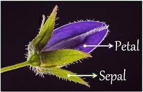

Энэхүү ажлаар дараах зүйлсийг сурна.

- CSV өгөдлийн файлыг уншиж, Pandas DataFrame обьектод хадгалах
- DataFrame обьектод хадгалагдсан өгөгдөл дээр янз бүрийн тойм статистикийг тооцоолох

**1.** Дараах код нь CSV файлыг уншиж, DataFrame объектод хадгалахад ашиглагддаг. Дараа нь өгөгдлийн эхний таван мөрийг харуулах болно.

```python
import pandas as pd

data = pd.read_csv('http://archive.ics.uci.edu/ml/machine-learning-databases/iris/iris.data',header=None)
data.columns = ['sepal length', 'sepal width', 'petal length', 'petal width', 'class']

data.head()
```

**2.** Тоон атрибут бүрийн хувьд дундаж, стандарт хазайлт, хамгийн их болон хамгийн бага утгыг тооцоолох

```python
from pandas.api.types import is_numeric_dtype

for col in data.columns:
    if is_numeric_dtype(data[col]):
        print('%s:' % (col))
        print('\t Mean = %.2f' % data[col].mean())
        print('\t Standard deviation = %.2f' % data[col].std())
        print('\t Minimum = %.2f' % data[col].min())
        print('\t Maximum = %.2f' % data[col].max())
```

**3.** Чанарын атрибутын хувьд (ангилал) түүний ялгаатай утга бүрийн давтамжийг тоолох.

```python
data['class'].value_counts()
```

**4.** describe() функцийг ашиглан бүх атрибутын хураангуй, тоймыг хүснэгтэд нэгэн зэрэг харуулах боломжтой. Атрибут нь тоон шинж чанартай бол түүний дундаж, стандарт хазайлт гэх мэт утгуудыг /mean, standard deviation, quantiles, minimum, median, maximum/, харин чанарын шинж чанартай бол unique болон top утгуудын /хамгийн их давтагдсан/ тоог харуулна.

```python
data.describe(include='all')
```

**count** нь атрибут бүрийн хувьд дутуу биш утгуудын (non-missing values) тоог илэрхийлнэ.

**5.** Олон хувьсагчийн статистикийн хувьд, хос атрибутуудын хооронд ковариац болон корреляцийг тооцоолж болно.

```python
print('Covariance:')
# data.cov()
data.select_dtypes(include='number').cov()
```

```python
print('Correlation:')
# data.corr()
data.select_dtypes(include='number').corr()
```

## Өгөгдлийн дүрслэл (Data Visualization)

Өгөгдлийн дүрслэл гэдэг нь мэдээллийг график эсвэл хүснэгт хэлбэрээр харуулах явдал. Амжилттай дүрслэхийн тулд өгөгдөл (мэдээлэл) нь визуал формат руу хөрвүүлэгдэх шаардлагатай бөгөөд ингэснээр өгөгдлийн онцлог, өгөгдлийн атрибутуудын хоорондын хамаарлыг шинжлэх эсвэл тайлагнаж болно.

Энэ хэсэгт өмнө авч үзсэн Цахилдаг цэцгийн (Iris) өгөгдлийг хэрхэн харуулах талаар сурах болно.

**1.** Эхлээд **sepal length** атрибутын хувьд гистограммыг (**histogram**) байгуулъя. Түүнийг 8 тусдаа хувинд (bin) хувааж, хувин бүр дэх давтамжийг тоолох замаар гистограммыг байгуулна.

%matplotlib inline нь зөвхөн jupyter notebook-т зориулагдсан бөгөөд хэрэв та өөр эдитор ашиглаж байгаа бол зураг зурах бүх командынхаа төгсгөлд plt.show()-г ашиглан зургийг өөр цонхонд харуулах болно гэдгийг санаарай.

```python
%matplotlib inline

data['sepal length'].hist(bins=8)
```

**2.** Мөн атрибут бүрийн утгын тархалтыг харуулахын тулд **boxplot** графикийг ашиглаж болно.

```python
data.boxplot()
```

**3.** Атрибутуудын хослол бүрт тэдний хамтын тархалтыг **scatter plot** графикаар харуулж болно.

```python
import matplotlib.pyplot as plt

colors = {'Iris-setosa':'red', 'Iris-versicolor':'green', 'Iris-virginica':'blue'}
fig, axes = plt.subplots(3, 2, figsize=(12,12))
index = 0
for i in range(3):
    for j in range(i+1,4):
        ax1 = int(index/2)
        ax2 = index % 2
        #axes[ax1][ax2].scatter(data[data.columns[i]], data[data.columns[j]], color='red')
        axes[ax1][ax2].scatter(data[data.columns[i]], data[data.columns[j]], c=data['class'].map(colors))
        axes[ax1][ax2].set_xlabel(data.columns[i])
        axes[ax1][ax2].set_ylabel(data.columns[j])
        index = index + 1
```

```python
import matplotlib.pyplot as plt
colors = {'Iris-setosa':'red', 'Iris-versicolor':'green', 'Iris-virginica':'blue'}

plt.scatter(data['petal length'], data['petal width'], c=data['class'].map(colors))
plt.title("Scatter Plot for bivariate analysis")
plt.xlabel('petal length')
plt.ylabel('petal width')
```

**4.** Параллель координат нь (**Parallel coordinates**) өгөгдлийн бүх цэгийг нэгэн зэрэг дүрслэн харуулахад ашиглагддаг. Параллель координат нь атрибут бүрийн хувьд нэг тэнхлэгтэй байдаг боловч эдгээр тэнхлэгүүд нь уламжлал ёсоор перпендикуляр биш харин параллель байна. Түүнчлэн объект бүр цэгээр биш шугамаар/шулуунаар дүрслэгдэнэ. Доорх жишээнд, ангилал тус бүрийн утгуудын тархалтыг тусад нь өнгөөр тодорхойлж болно.

```python
from pandas.plotting import parallel_coordinates
%matplotlib inline

parallel_coordinates(data, 'class')
```

## Дасгал

### Өгөгдлийн дүрслэл

**I.** Iris өгөгдлийн 3 төрлийн цэцэг бүрийн 4 атрибутын дундаж утгыг barplot графикаар дүрслэн харуулна. График зурахад дараах аргуудын аль нэгийг ашиглаж болно:

**a)** matplotlib сангийн pyplot модулийг ашиглах.

**b)** эсвэл seaborn сангийн barplot() функцийг ашиглах.

Seaborn бол matplotlib дээр суурилсан өгөгдлийн дүрслэлийн Python сан юм. Энэ нь мэдээлэл сайтай, статистик график зурах өндөр түвшний интерфейсээр хангадаг.

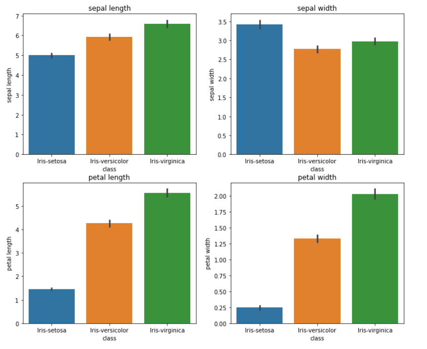

**II.** scatter plot-н өргөжүүлсэн хувилбар болох дараах графикийг мөн дээрх өгөгдөл дээр дүрсэлж харна уу.

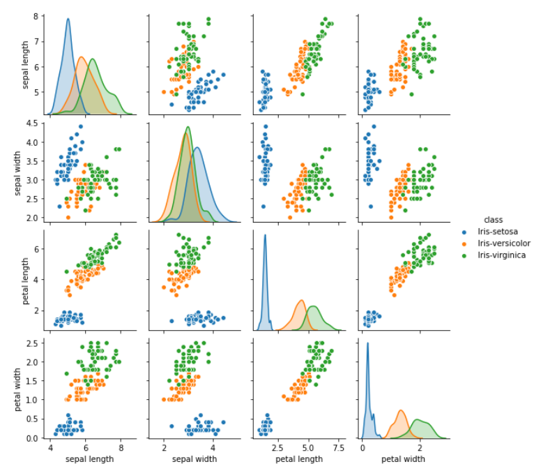

**III.** Heat map нь өгөгдлийн утгуудыг матриц хэлбэрээр өнгөөр кодлон дүрсэлдэг график дүрслэлийн арга юм. Энэ нь хоёр хэмжээст матриц дахь тоон утгуудад өнгө оноох замаар атрибутуудын хоорондын хамаарлыг ойлгомжтой байдлаар илэрхийлдэг.

Дээр өгөгдсөн Iris dataset-ийн атрибутуудын хоорондын корреляцийн матрицыг тооцоолж, seaborn сангийн heatmap() функцийг ашиглан дүрслэн харуул.

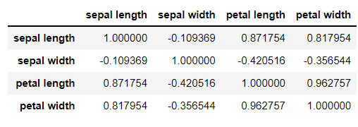

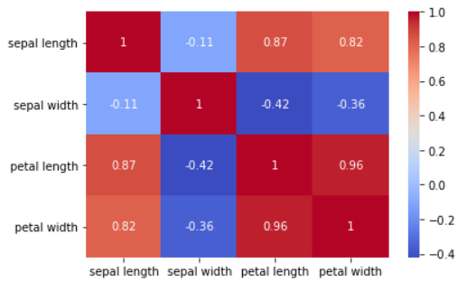

### Ижил болон ялгаатай байдал

**IV.** **Eucledian distance:** Евклидийн зай бол хамгийн түгээмэл хэрэглэгддэг зайн хэмжүүр юм. - Евклидийн зайг олох функц тодорхойлно уу - Дараах 2 обьектын хоорондох зайг олно уу.

```
x = [0,3,4,5]
y = [7,6,3,-1]
```

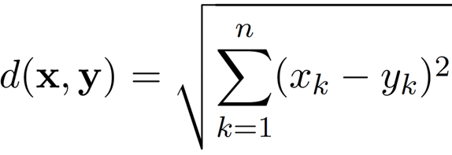

**V.** **Manhattan distance:**

```
p1 нь (x1, y1), p2 нь (x2, y2) үед
Манхэттэн зай = |x1 – x2| + |y1 – y2|
```

```
- Манхэттэний зайг олох функц тодорхойлно уу.
- Дараах 2 обьектын хоорондох зайг олно уу.
```

```
x = [10,20,10]
y = [10,20,20]
```

**VI.**. **Minkowski distance:** Минковскийн зай нь Евклидийн зай болон Манхэттэний зайн ерөнхий хэлбэр. - r = 1 Манхэттэний зай - r = 2 Евклидийн зай - r = ∞ Чебышевын зай

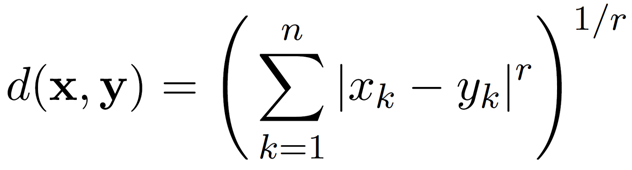

```
- Минковскийн зайг олох функц бич.
- Дараах 2 обьектын хоорондох зайг олно уу (r = 3).
```

```
x = [0,3,4,5]
y = [7,6,3,-1]
```

**VII.** **Cosine similarity** Үүнийг түгээмэл ашиглах болсон нэг шалтгаан нь сийрэг векторуудыг үнэлэхэд маш үр дүнтэй байдаг.

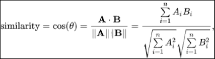

```
- Cosine similarity олох функц бич
- Дараах 2 обьектын косинусын ижил төстэй байдлыг олно уу.
```

```
x = [3, 45, 7, 2]
y = [2, 54, 13, 15]
```

**VIII.** **Jaccard Similarity:** Жаккардын ижил төстэй байдал нь хязгаарлагдмал түүврийн олонлогуудын ижил төстэй байдлыг хэмждэг.

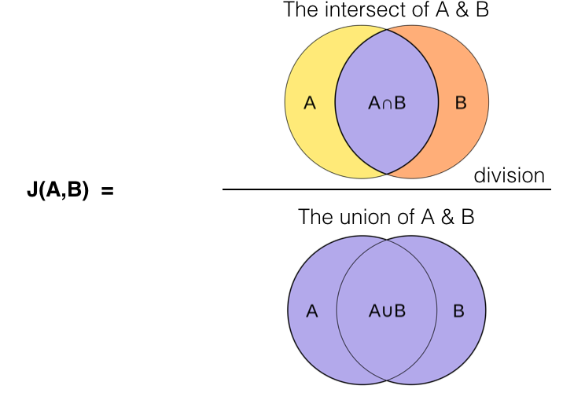

```
- Jaccard Similarity олох функцийг тодорхойл  / set.intersection(), set.union() /
- Дараах 2 обьектын Жаккардын ижил төстэй байдлыг олно уу
```

```
x = [0,1,2,5,6]
y = [0,2,3,5,7,9]
```

**IX.** Өгөгдсөн объектуудын хоорондын ижил төстэй байдлыг Gower-ийн similarity коэффициент ашиглан тооцоолж, үр дүнг тайлбарлана уу.

```
data = pd.DataFrame({
    'Age':       [25, 30, 22, 40, 35],
    'Income':    [2.5, 3.0, 1.8, 4.2, 3.5],
    'Gender':    ['Male', 'Female', 'Female', 'Male', 'Male'],
    'Married':   ['Yes', 'No', 'No', 'Yes', 'Yes'],
    'Education': ['Bachelor', 'Master', 'Bachelor', 'PhD', 'Master']
})
```